[GitHub](https://github.com/JuliaGeometry/DelaunayTriangulation.jl)[](https://github.com/JuliaGeometry/DelaunayTriangulation.jl/tree/main/docs/src/literate_tutorials/unconstrained.jl)

# Unconstrained Triangulations

Our first example considers constructing unconstrained Delaunay triangulations. To start, let us load in the packages we will need.

```julia
using DelaunayTriangulation
using CairoMakie # for plotting
using StableRNGs # for reproducibility
using LinearAlgebra # used for computing norms later
```

We consider just triangulating a random set of points. First, generating the points:

```julia
rng = StableRNG(123)
points = rand(rng, 2, 500) # just do rand(2, 500) if you are not concerned about the RNG
```

```
2×500 Matrix{Float64}:
 0.181026  0.669058   0.437991  0.763974  0.515045  0.70134   0.876273  0.739213  0.506876  0.266373  0.351618  0.721093  0.637996  0.363447  0.455205  0.348518  0.809794  0.223906  0.61295   0.329471  0.540632  0.223046  0.539128  0.419776  0.458012  0.687042  0.15147   0.785806  0.336894  0.343754  0.418788  0.256693  0.0639703  0.331352   0.244427  0.425703  0.491863  0.776779  0.360371  0.00263946  0.340133   0.270424  0.115997  0.813952   0.421372  0.722946  0.552395  0.797896  0.523122  0.288461  0.545081  0.437921  0.304731  0.89046   0.637476  0.813697  0.69858   0.151131  0.793309   0.329285    0.562948  0.0815702  0.279641   0.817653  0.801687  0.695043  0.307854  0.377544  0.558266  0.824428  0.796442  0.154541  0.0800997  0.691939  0.167874  0.933698  0.93185   0.791387  0.82006   0.708238   0.95372  0.753526  0.74857  0.659175  0.209896  0.196745  0.127467  0.524392  0.0829614  0.700979  0.134585  0.00688858  0.51353   0.24561   0.163308  0.435777  0.918945   0.166482  0.0568971  0.406672  0.527439  0.4354     0.21018   0.43972   0.301404  0.583691  0.874586   0.387704  0.350605  0.502661  0.582974  0.151539  0.276187  0.880838  0.152898  0.277676  0.549405  0.163404  0.129285  0.131234  0.196663  0.80264   0.869203  0.112288   0.110314  0.458535  0.784782   0.250383  0.917494  0.488987  0.54606   0.185561  0.995848  0.762547  0.308271  0.510413  0.178851  0.634063  0.931508  0.213869    0.183094  0.532255  0.625907  0.65799   0.628808  0.799758  0.481242  0.940936  0.881986  0.374775  0.374894   0.69412   0.932955   0.764663  0.101373  0.74717   0.905268  0.646034  0.230818  0.736922  0.327148  0.624086  0.978315   0.676679  0.675824  0.76549   0.310209  0.0560602  0.977099  0.400777  0.385446  0.153937  0.628224  0.0259813  0.556082  0.00130711  0.587556  0.521749  0.362642  0.517127  0.755883  0.153261  0.199942  0.301887   0.828024  0.0927618  0.622874  0.207796  0.022725  0.234718  0.1874    0.559458  0.402361  0.737495  0.100388  0.394142  0.796617  0.491243  0.435373  0.676698  0.601822  0.912472  0.65373  0.800586  0.665684  0.656845  0.925526  0.733754  0.106838  0.828335  0.431333   0.00736147  0.921623  0.507653  0.971479  0.269747  0.817207  0.215851  0.609782  0.711618  0.226012  0.539521  0.261726  0.66208   0.899939  0.876967  0.284227  0.351236  0.965389  0.949363  0.237952  0.998855  0.315107  0.0404263  0.675675  0.310525  0.791587  0.0233863  0.0955889  0.896359  0.762741  0.828236  0.769262  0.47533  0.063996    0.755876  0.973318  0.146077  0.770016  0.61136    0.263433  0.94654   0.906265  0.827459  0.966827  0.489265  0.987065  0.824262   0.288757  0.30942   0.195225  0.324369  0.529757  0.212361  0.900904  0.88208   0.511181  0.751019  0.420527   0.883097  0.219401  0.323676   0.637138   0.118389  0.868121  0.409298  0.270215  0.453449  0.123123  0.811252   0.389822   0.145426  0.820001  0.257654  0.135927  0.709894  0.462429  0.446925  0.856169  0.806983    0.881146  0.974744  0.167324  0.955413  0.967742  0.341459  0.958273  0.858018  0.621369  0.456395  0.503465  0.323223  0.0752862  0.955472  0.52896   0.902039  0.357986  0.237799  0.571431  0.834022  0.176041   0.788659  0.29665   0.554148  0.644947  0.954224  0.776911  0.620958   0.00291754  0.095197   0.0210285  0.664658   0.762682   0.484171  0.921929   0.901151  0.668319  0.262004  0.386269   0.436472  0.824224  0.683262  0.340386  0.117477  0.733987  0.442351  0.989014  0.978268  0.1671    0.330902  0.741137   0.554488  0.548208  0.616783  0.972508  0.266814  0.170246  0.410809  0.262931  0.755769   0.422182  0.604407   0.817767  0.974785  0.955647  0.739929  0.320489  0.62935   0.21621   0.272473   0.601508  0.414413  0.804268  0.196294  0.974554  0.583934    0.335481  0.539881  0.300205  0.337433  0.0202547  0.296958  0.494453  0.11217   0.0715926  0.564346  0.571969  0.53193   0.157119  0.289274  0.388633  0.779599   0.911604  0.117072  0.898052  0.462633  0.761786  0.505131  0.467784  0.0493592  0.0923198  0.0449557  0.135861  0.635555  0.909697  0.613948  0.279111  0.857699    0.00524744  0.120045  0.429042  0.0882701  0.193549  0.398813  0.610383  0.401103  0.53577   0.170252   0.872609  0.438583  0.750883  0.865202  0.266392   0.711303  0.637627  0.089177  0.410576  0.303547  0.894829  0.125559  0.473098  0.464572  0.806659   0.221016   0.0280905  0.810146   0.00827066  0.804782  0.0616697  0.941801  0.250919  0.237675  0.823915  0.541156  0.720895  0.803985  0.0786536  0.236702  0.956706  0.640619  0.958435  0.82819   0.882578  0.597655  0.564413  0.837944  0.418879  0.53278   0.818377  0.975019  0.382218  0.0698097  0.459689   0.236278  0.235126  0.0313331  0.537227  0.263279  0.460627  0.473966  0.944432  0.623716  0.785133  0.0120468  0.603183  0.0428481  0.145068  0.989866  0.413146  0.47412   0.762582  0.761679  0.968606  0.667712  0.253657  0.713645   0.181444   0.521983  0.0227201  0.0828667  0.259405  0.959931  0.42234   0.875965   0.353899  0.927026  0.62526   0.596537  0.973425  0.941601   0.0438116  0.911062   0.739358  0.864538  0.699831  0.400533  0.337066  0.459817   0.312727  0.0634304
 0.36749   0.0427306  0.48329   0.924483  0.495042  0.693569  0.944219  0.559545  0.646024  0.253141  0.527389  0.188512  0.427843  0.577647  0.16582   0.737079  0.171167  0.848205  0.952542  0.918373  0.820474  0.598776  0.619535  0.453259  0.836069  0.353959  0.703671  0.551635  0.710355  0.405438  0.346188  0.157176  0.596071   0.0965347  0.128071  0.926538  0.134549  0.597526  0.034642  0.604342    0.0888438  0.290691  0.847073  0.0601803  0.679816  0.737598  0.970875  0.683298  0.855341  0.431233  0.638433  0.775729  0.745173  0.139747  0.856516  0.777063  0.152194  0.324202  0.0924124  0.00563978  0.579165  0.450706   0.0560835  0.50384   0.65171   0.389672  0.381893  0.7932    0.707537  0.515592  0.327837  0.817693  0.0475871  0.819659  0.125727  0.493807  0.311002  0.765118  0.521854  0.0734049  0.17116  0.90863   0.66635  0.63634   0.221245  0.241482  0.478185  0.390411  0.0617778  0.648669  0.308804  0.541835    0.428168  0.496737  0.545666  0.911066  0.0662768  0.649396  0.760846   0.248483  0.401041  0.0396139  0.900348  0.939905  0.873122  0.80144   0.0770524  0.506864  0.428658  0.121242  0.638559  0.974467  0.639326  0.835716  0.207941  0.592121  0.506314  0.186599  0.794883  0.802221  0.160557  0.191487  0.481045  0.0205251  0.751321  0.692231  0.0247294  0.521179  0.42381   0.890044  0.341701  0.48763   0.457178  0.452692  0.724959  0.192477  0.55463   0.513373  0.739426  0.00516507  0.42228   0.409429  0.843826  0.829954  0.53278   0.345138  0.571183  0.509987  0.33359   0.358201  0.0316704  0.686877  0.0452453  0.633021  0.100261  0.801601  0.203674  0.930138  0.222399  0.889327  0.93828   0.387938  0.0555843  0.348795  0.339641  0.294326  0.362177  0.876946   0.569376  0.550425  0.561675  0.154164  0.152203  0.36556    0.111442  0.735052    0.389202  0.886379  0.15633   0.144373  0.237032  0.145793  0.45279   0.0372542  0.440216  0.18769    0.692835  0.808651  0.622941  0.854403  0.373967  0.186052  0.246232  0.579073  0.1812    0.852832  0.999781  0.989092  0.776308  0.423385  0.843372  0.674218  0.1239   0.313695  0.38427   0.559683  0.207026  0.745099  0.331923  0.138651  0.0398031  0.391087    0.840941  0.487405  0.140799  0.904586  0.210664  0.543117  0.999184  0.260491  0.637879  0.154327  0.428806  0.533854  0.584642  0.63172   0.205341  0.473755  0.813529  0.46243   0.534511  0.361381  0.158313  0.151782   0.189559  0.036348  0.645382  0.865508   0.857054   0.529265  0.726127  0.417632  0.103866  0.97594  0.00780044  0.2739    0.930787  0.410755  0.676963  0.0768056  0.762454  0.868867  0.558984  0.736597  0.114093  0.867234  0.482919  0.0028658  0.309163  0.904961  0.828557  0.986628  0.199129  0.567569  0.977771  0.575212  0.401379  0.831577  0.0412443  0.459265  0.82129   0.0788373  0.0171894  0.853996  0.154636  0.062491  0.165524  0.091407  0.448646  0.0171893  0.0980491  0.855286  0.214436  0.1485    0.151223  0.751848  0.239441  0.27903   0.48538   0.00820996  0.560848  0.669526  0.014872  0.133648  0.057047  0.8933    0.401493  0.53216   0.800628  0.380869  0.507253  0.308986  0.952318   0.634803  0.262183  0.826332  0.132768  0.325102  0.407019  0.901277  0.0935133  0.835246  0.069461  0.122496  0.283896  0.486517  0.719179  0.0950475  0.0327314   0.0761925  0.433444   0.0667151  0.0517945  0.194546  0.0116186  0.633291  0.319646  0.455837  0.0323374  0.39123   0.72488   0.366719  0.930497  0.840097  0.560529  0.462569  0.374708  0.683058  0.150342  0.728512  0.0959656  0.286593  0.903991  0.196968  0.989066  0.199721  0.502435  0.14738   0.265107  0.0416473  0.114756  0.0747264  0.170444  0.747839  0.311876  0.497515  0.970706  0.429969  0.940689  0.0109684  0.674098  0.889181  0.642075  0.132777  0.103044  0.00559392  0.917282  0.645921  0.181392  0.76393   0.936732   0.388988  0.56209   0.929056  0.498177   0.707023  0.344282  0.919879  0.284647  0.632842  0.910668  0.0279172  0.328333  0.455078  0.370364  0.58211   0.803457  0.082038  0.861727  0.640028   0.705404   0.15266    0.896605  0.391123  0.420594  0.115443  0.43585   0.00436228  0.152666    0.933136  0.858691  0.0127729  0.964708  0.610086  0.136407  0.892495  0.815915  0.0629032  0.761915  0.17202   0.528866  0.537323  0.0417917  0.20407   0.705418  0.954324  0.576491  0.642704  0.800022  0.564916  0.195492  0.485029  0.0980802  0.0581283  0.960441   0.0577736  0.738122    0.604437  0.0428863  0.894244  0.96158   0.262416  0.573678  0.831426  0.32834   0.494434  0.375363   0.308775  0.964644  0.092962  0.534357  0.230757  0.811912  0.300044  0.614219  0.986509  0.770094  0.321493  0.549143  0.277844  0.929055  0.88323    0.0785272  0.872782  0.303657  0.962391   0.310815  0.47404   0.865449  0.815715  0.934553  0.534671  0.535503  0.458238   0.66025   0.206327   0.349035  0.980125  0.415568  0.171304  0.683687  0.414906  0.317704  0.818032  0.235651  0.0368418  0.0666789  0.813251  0.860372   0.189548   0.222904  0.550917  0.271007  0.0716159  0.188967  0.862459  0.933695  0.554072  0.827465  0.0370543  0.836151   0.0143462  0.494221  0.638122  0.395067  0.175565  0.942264  0.0794176  0.892313  0.606559
```

We now triangulate these points by using `triangulate`. We pass the `rng` as a keyword argument, but again if you are not concerned about the RNG (or set the seed using `Random.seed!`) then you can ignore this.

```julia
tri = triangulate(points; rng=rng)
```

```
Delaunay Triangulation.
   Number of vertices: 500
   Number of triangles: 980
   Number of edges: 1479
   Has boundary nodes: false
   Has ghost triangles: true
   Curve-bounded: false
   Weighted: false
   Constrained: false
```

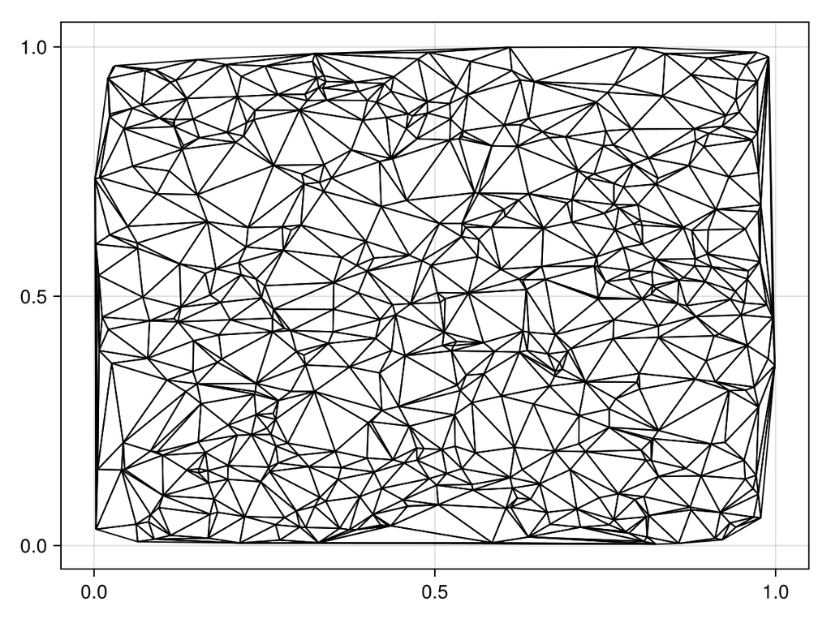

```julia
fig, ax, sc = triplot(tri)
fig
```

This `tri` object is our `Triangulation`, and we can interact with it in many ways.

## Iterating over vertices

For example, we can iterate over the points in the triangulation using `each_solid_vertex`. Here we compute the centroid of the point cloud:

```julia
function compute_centroid(tri)
    s = [0.0, 0.0]
    for i in each_solid_vertex(tri)
        p = get_point(tri, i)
        s .+= p
    end
    s ./= num_solid_vertices(tri)
    return s
end
s = compute_centroid(tri)
```

```
2-element Vector{Float64}:
 0.5106629621450203
 0.477077379328767
```

We need to use the `solid` identifier because triangulations are made up of both *solid* and *ghost* vertices/edges/triangles, for reasons described in the manual. If we just use `each_vertex(tri)`, then we also find a vertex `-1` that corresponds to the boundary. For example, the points on the boundary can be obtained using:

```julia
get_neighbours(tri, -1)
```

```
Set{Int64} with 18 elements:
  456
  176
  425
  258
  325
  398
  197
  219
  319
  262
  112
  345
  371
  232
  245
  163
  468
  140
```

One reason to be careful with this especially is that `get_point(tri, -1)` does actually correspond to a coordinate,

```julia
get_point(tri, -1)
```

```
(0.500547641525688, 0.497711096515429)
```

(This is the pole of inaccessibility for the domain; see here for more details.) You can use `each_vertex` or `each_ghost_vertex` to consider all types of vertices or only the ghost vertices. If you just want the vertices, use `each_vertex(tri)`, which will also include the ghost vertex.

```julia
each_vertex(tri)
```

```
Set{Int64} with 501 elements:
  319
  185
  420
  365
  422
  263
  242
  183
  224
  177
  77
  172
  103
  59
  211
  358
  366
  414
  116
  79
  279
  485
  46
  152
  250
  448
  438
  436
  454
  154
  206
  500
  40
  245
  325
  145
  444
  342
  457
  460
  351
  158
  92
  118
  162
  494
  93
  304
  18
  349
  368
  217
  61
  412
  212
  474
  223
  285
  198
  331
  80
  51
  490
  143
  330
  284
  419
  367
  186
  90
  456
  316
  179
  52
  369
  356
  487
  85
  406
  10
  261
  484
  340
  329
  466
  241
  236
  190
  14
  357
  403
  123
  305
  197
  233
  196
  408
  324
  54
  327
  62
  205
  483
  122
  58
  385
  321
  318
  87
  317
  248
  202
  455
  160
  289
  49
  396
  131
  373
  53
  492
  286
  181
  446
  56
  429
  425
  60
  220
  308
  67
  215
  404
  168
  431
  364
  479
  75
  111
  66
  280
  374
  141
  278
  477
  450
  135
  138
  107
  170
  238
  22
  391
  288
  400
  113
  283
  309
  55
  265
  136
  117
  218
  28
  84
  203
  353
  292
  232
  240
  147
  415
  146
  390
  380
  424
  193
  226
  488
  17
  271
  335
  426
  89
  214
  48
  493
  134
  473
  253
  64
  394
  410
  486
  300
  171
  478
  216
  108
  382
  2
  27
  124
  273
  312
  290
  20
  81
  398
  9
  189
  409
  249
  395
  372
  88
  260
  37
  121
  311
  281
  174
  496
  322
  269
  262
  320
  151
  244
  434
  277
  377
  34
  50
  243
  194
  301
  458
  -1
  106
  102
  259
  379
  21
  440
  192
  362
  47
  407
  178
  387
  306
  472
  155
  293
  499
  73
  251
  115
  112
  86
  207
  465
  430
  23
  264
  41
  68
  130
  125
  339
  336
  343
  468
  100
  230
  195
  388
  222
  276
  381
  247
  184
  1
  435
  137
  427
  237
  270
  33
  254
  482
  165
  142
  416
  5
  45
  418
  449
  282
  393
  437
  148
  36
  7
  95
  25
  296
  476
  341
  287
  19
  44
  266
  31
  29
  303
  159
  463
  101
  360
  462
  246
  97
  402
  413
  110
  30
  234
  272
  182
  164
  470
  267
  4
  359
  328
  69
  11
  119
  495
  307
  144
  257
  352
  200
  187
  213
  227
  109
  445
  453
  498
  120
  297
  24
  464
  433
  447
  314
  480
  315
  268
  497
  32
  471
  239
  191
  150
  199
  361
  98
  411
  310
  169
  180
  428
  347
  375
  332
  229
  163
  467
  338
  3
  96
  35
  348
  417
  333
  376
  12
  82
  71
  208
  26
  127
  389
  295
  57
  475
  397
  129
  78
  133
  72
  258
  252
  313
  354
  299
  345
  231
  432
  114
  337
  275
  363
  378
  176
  469
  451
  157
  392
  16
  370
  489
  74
  228
  105
  399
  421
  166
  274
  15
  6
  219
  153
  139
  13
  405
  104
  302
  43
  39
  443
  126
  441
  156
  439
  346
  344
  294
  481
  161
  383
  401
  209
  323
  8
  83
  201
  99
  491
  386
  461
  334
  423
  210
  63
  91
  173
  256
  188
  355
  235
  204
  384
  371
  76
  167
  42
  132
  140
  442
  255
  291
  452
  94
  225
  128
  70
  350
  38
  326
  221
  175
  459
  149
  65
  298
```

## Iterating over edges

We can also iterate over the edges of the triangulation using `each_solid_edge`, or `each_edge` for both solid and ghost edges and `each_ghost_edge` for only the ghost edges. To give an example, here we compute the average length of an edge.

```julia
function compute_mean_edge_length(tri)
    ℓ = 0.0
    for e in each_solid_edge(tri)
        u, v = edge_vertices(e)
        p, q = get_point(tri, u, v)
        ℓ += norm(p .- q)
    end
    ℓ /= num_solid_edges(tri)
    return ℓ
end
ℓ = compute_mean_edge_length(tri)
```

```
0.05645693808033534
```

By default, the triangulation has ghost edges, so `each_edge` and `each_solid_edge` are not the same.

```julia
each_edge(tri)
```

```
Set{Tuple{Int64, Int64}} with 1497 elements:
  (453, 388)
  (276, 329)
  (17, 12)
  (382, 127)
  (4, 197)
  (366, 352)
  (34, 313)
  (407, 106)
  (114, 56)
  (194, 90)
  (263, 136)
  (498, 388)
  (345, 446)
  (343, 47)
  (375, 33)
  (412, 433)
  (292, 304)
  (290, 127)
  (274, 334)
  (427, 176)
  (29, 16)
  (435, 472)
  (124, 320)
  (424, 311)
  (272, 41)
  (63, 413)
  (458, 50)
  (208, 156)
  (404, 171)
  (94, 132)
  (261, 103)
  (229, 139)
  (250, 352)
  (358, 117)
  (412, 240)
  (237, 363)
  (196, 199)
  (55, 158)
  (11, 228)
  (149, 442)
  (299, 286)
  (451, 36)
  (217, 353)
  (241, 471)
  (338, 139)
  (379, 186)
  (410, 496)
  (167, 30)
  (359, 403)
  (452, 371)
  (112, -1)
  (372, 223)
  (480, 195)
  (322, 80)
  (138, 145)
  (277, 284)
  (219, 19)
  (243, 57)
  (24, 336)
  (271, 18)
  (262, 244)
  (140, 413)
  (116, 128)
  (183, 328)
  (312, 82)
  (296, 499)
  (235, 173)
  (239, 274)
  (43, 334)
  (78, 156)
  (150, 483)
  (34, 284)
  (26, 165)
  (494, 65)
  (273, 322)
  (234, 392)
  (356, 224)
  (346, 159)
  (381, 406)
  (262, 198)
  (481, 159)
  (345, 439)
  (423, 210)
  (6, 83)
  (255, 97)
  (154, 38)
  (82, 160)
  (282, 261)
  (147, 9)
  (402, 73)
  (170, 171)
  (445, 23)
  (468, -1)
  (230, 316)
  (11, 14)
  (115, 186)
  (175, 110)
  (24, 228)
  (442, 246)
  (466, 480)
  (248, 191)
  (122, 17)
  (292, 338)
  (430, 252)
  (447, 68)
  (410, 348)
  (48, 249)
  (272, 236)
  (20, 333)
  (174, 212)
  (71, 435)
  (452, 374)
  (300, 93)
  (491, 334)
  (221, 135)
  (279, 132)
  (26, 435)
  (74, 286)
  (44, 484)
  (370, 53)
  (402, 293)
  (19, 47)
  (422, 170)
  (129, 270)
  (483, 193)
  (317, 471)
  (216, 260)
  (195, 186)
  (448, 288)
  (300, 88)
  (36, 406)
  (230, 133)
  (93, 117)
  (104, 36)
  (99, 491)
  (327, 315)
  (474, 144)
  (140, 360)
  (199, 68)
  (279, 384)
  (497, 357)
  (247, 252)
  (423, 44)
  (202, 226)
  (78, 317)
  (296, 406)
  (450, 473)
  (184, 313)
  (438, 42)
  (74, 156)
  (294, 215)
  (447, 16)
  (338, 468)
  (443, 56)
  (354, 139)
  (381, 367)
  (61, 117)
  (480, 392)
  (308, 191)
  (97, 484)
  (160, 268)
  (386, 404)
  (136, 180)
  (369, 227)
  (143, 144)
  (245, 140)
  (89, 124)
  (181, 414)
  (3, 336)
  (6, 286)
  (130, 389)
  (148, 316)
  (155, 320)
  (336, 330)
  (183, 141)
  (151, 281)
  (243, 12)
  (496, 348)
  (60, 366)
  (457, 288)
  (109, 469)
  (452, 303)
  (62, 464)
  (10, 227)
  (371, 479)
  (130, 244)
  (495, 472)
  (254, 78)
  (121, 118)
  (282, 72)
  (461, 7)
  (316, 257)
  (24, 469)
  (478, 460)
  (371, 168)
  (108, 3)
  (291, 266)
  (321, 464)
  (84, 206)
  (279, 141)
  (481, 346)
  (179, 307)
  (106, 376)
  (225, 266)
  (292, 169)
  (412, 291)
  (213, 306)
  (74, 160)
  (280, 426)
  (245, 402)
  (273, 290)
  (390, 500)
  (122, 353)
  (452, 168)
  (220, 315)
  (162, 164)
  (91, 209)
  (385, 297)
  (405, 396)
  (28, 411)
  (273, 2)
  (256, 25)
  (240, 253)
  (126, 45)
  (373, 422)
  (296, 367)
  (129, 230)
  (138, 358)
  (260, 20)
  (206, 462)
  (167, 67)
  (150, 469)
  (488, 206)
  (377, 162)
  (235, 220)
  (335, 206)
  (255, 215)
  (59, 423)
  (350, 476)
  (133, 468)
  (487, 55)
  (22, 116)
  (155, 311)
  (167, 308)
  (42, 308)
  (450, 77)
  (354, 468)
  (166, 435)
  (345, 468)
  (398, 325)
  (350, 323)
  (69, 106)
  (113, 116)
  (145, 462)
  (441, 482)
  (213, 114)
  (215, 365)
  (351, 278)
  (309, 358)
  (25, 389)
  (493, 436)
  (453, 102)
  (322, 2)
  (386, 45)
  (461, 439)
  (272, 313)
  (385, 149)
  (335, 411)
  (345, 197)
  (59, 44)
  (233, 307)
  (205, 200)
  (255, 294)
  (429, 319)
  (499, 260)
  (41, 281)
  (459, 401)
  (215, 232)
  (64, 436)
  (138, 224)
  (11, 458)
  (480, 379)
  (324, 136)
  (318, 352)
  (189, 500)
  (97, 295)
  (493, 134)
  (420, 95)
  (113, 380)
  (316, 76)
  (231, 264)
  (344, 405)
  (476, 127)
  (456, 371)
  (377, 342)
  (119, 72)
  (115, 118)
  (354, 489)
  (447, 52)
  (428, 363)
  (276, 281)
  (486, 310)
  (452, 393)
  (160, 144)
  (377, 444)
  (223, 141)
  (378, 130)
  (489, 468)
  (309, 177)
  (213, 252)
  (370, 105)
  (59, 323)
  (434, 478)
  (437, 212)
  (450, 232)
  (312, 310)
  (109, 50)
  (273, 250)
  (339, 118)
  (432, 86)
  (208, 241)
  (154, 83)
  (414, 220)
  (310, 114)
  (120, 72)
  (96, 362)
  (195, 118)
  (466, 234)
  (499, 20)
  (289, 70)
  (16, 68)
  (370, 68)
  (261, 188)
  (160, 55)
  (23, 9)
  (15, 421)
  (383, 385)
  (373, 117)
  (48, 471)
  (302, 483)
  (480, 186)
  (256, 49)
  (64, 79)
  (494, 266)
  (43, 274)
  (313, 236)
  (438, 308)
  (368, 111)
  (28, 433)
  (173, 405)
  (298, 449)
  (283, 353)
  (175, 396)
  (130, 96)
  (225, 482)
  (306, 229)
  (182, 285)
  (105, 68)
  (279, 437)
  (324, 470)
  (322, 250)
  (340, 135)
  (63, 184)
  (76, 270)
  (499, 216)
  (84, 415)
  (237, 249)
  (147, 422)
  (157, 207)
  (219, 197)
  (461, 247)
  (42, 455)
  (446, 265)
  (103, 393)
  (245, 429)
  (205, 164)
  (382, 426)
  (33, 92)
  (194, 206)
  (328, 223)
  (439, 468)
  (51, 111)
  (163, -1)
  (370, 16)
  (181, 283)
  (466, 91)
  (62, 384)
  (445, 51)
  (194, 154)
  (132, 87)
  (335, 224)
  (254, 409)
  (273, 366)
  (177, 131)
  (46, 286)
  (216, 103)
  (104, 130)
  (78, 387)
  (410, 193)
  (493, 224)
  (330, 31)
  (370, 251)
  (214, 422)
  (116, 418)
  (79, 449)
  (175, 405)
  (54, 107)
  (87, 384)
  (1, 467)
  (456, 303)
  (326, 202)
  (105, 190)
  (298, 289)
  (80, 341)
  (45, 9)
  (85, 159)
  (54, 97)
  (181, 442)
  (150, 330)
  (138, 117)
  (312, 268)
  (91, 58)
  (201, 343)
  (133, 337)
  (185, 289)
  (408, 477)
  (22, 221)
  (105, 251)
  (420, 33)
  (80, 476)
  (185, 270)
  (17, 353)
  (35, 313)
  (60, 140)
  (55, 144)
  (69, 368)
  (448, 131)
  (432, 10)
  (113, 221)
  (378, 178)
  (69, 376)
  (242, 270)
  (100, 410)
  (80, 323)
  (189, 390)
  (340, 29)
  (488, 84)
  (487, 19)
  (437, 467)
  (84, 187)
  (163, 295)
  (470, 37)
  (90, 83)
  (420, 87)
  (420, 137)
  (99, 125)
  (378, 47)
  (309, 117)
  (445, 61)
  (137, 347)
  (54, 210)
  (425, 371)
  (473, 232)
  (429, 234)
  (473, 297)
  (19, 158)
  (415, 187)
  (237, 428)
  (248, 141)
  (267, 93)
  (496, 193)
  (25, 460)
  (487, 201)
  (464, 212)
  (358, 13)
  (307, 281)
  (333, 367)
  (191, 223)
  (472, 134)
  (301, 214)
  (296, 20)
  (476, 290)
  (262, 497)
  (67, 30)
  (205, 66)
  (22, 113)
  (194, 335)
  (457, 131)
  (75, 182)
  (222, 180)
  (267, 88)
  (299, 106)
  (258, -1)
  (279, 248)
  (243, 17)
  (53, 135)
  (279, 87)
  (436, 289)
  (35, 284)
  (307, 348)
  (476, 2)
  (461, 430)
  (175, 388)
  (48, 65)
  (277, 32)
  (243, 59)
  (474, 286)
  (242, 385)
  (157, 275)
  (28, 38)
  (345, -1)
  (438, 455)
  (181, 246)
  (208, 78)
  (104, 451)
  (456, 425)
  (256, 130)
  (397, 458)
  (33, 500)
  (40, 33)
  (357, 431)
  (332, 26)
  (220, 246)
  (465, 361)
  (403, 431)
  (95, 347)
  (310, 82)
  (263, 222)
  (397, 50)
  (76, 123)
  (237, 154)
  (250, 318)
  (395, 297)
  (283, 442)
  (493, 200)
  (93, 5)
  (162, 165)
  (4, 158)
  (93, 142)
  (238, 371)
  (497, 333)
  (278, 110)
  (466, 209)
  (211, 276)
  (176, -1)
  (369, 346)
  (450, 355)
  (32, 121)
  (324, 287)
  (377, 177)
  (69, 9)
  (361, 368)
  (488, 117)
  (361, 376)
  (486, 213)
  (219, 47)
  (482, 253)
  (287, 410)
  (136, 470)
  (240, 291)
  (196, 296)
  (387, 268)
  (366, 388)
  (443, 306)
  (60, 360)
  (322, 203)
  (279, 62)
  (301, 422)
  (264, 116)
  (419, 443)
  (432, 475)
  (494, 202)
  (464, 92)
  (302, 10)
  (331, 254)
  (298, 123)
  (438, 58)
  (148, 253)
  (273, 352)
  (357, 161)
  (188, 251)
  (138, 462)
  (196, 401)
  (359, 216)
  (316, 441)
  (451, 367)
  (207, 77)
  (64, 70)
  (57, 80)
  (27, 221)
  (472, 146)
  (471, 249)
  (299, 143)
  (11, 108)
  (58, 209)
  (169, 304)
  (180, 37)
  (340, 53)
  (390, 391)
  (58, 308)
  (263, 305)
  (172, 339)
  (267, 300)
  (113, 135)
  (228, 458)
  (197, 446)
  (24, 3)
  (489, 252)
  (424, 140)
  (107, 210)
  (401, 362)
  (351, 276)
  (266, 253)
  (481, 10)
  (302, 259)
  (456, 416)
  (485, 233)
  (400, 374)
  (194, 84)
  (228, 50)
  (219, -1)
  (478, 69)
  (11, 171)
  (344, 192)
  (27, 119)
  (100, 193)
  (443, 114)
  (147, 170)
  (331, 202)
  (54, 294)
  (444, 327)
  (463, 436)
  (397, 223)
  (331, 317)
  (213, 229)
  (376, 368)
  (221, 251)
  (35, 121)
  (62, 437)
  (470, 180)
  (203, 173)
  (378, 244)
  (107, 423)
  (454, 105)
  (440, 203)
  (25, 199)
  (348, 281)
  (419, 139)
  (126, 52)
  (140, 293)
  (103, 403)
  (490, 153)
  (24, 108)
  (236, 39)
  (168, 491)
  (14, 418)
  (40, 399)
  (463, 411)
  (6, 90)
  (424, 413)
  (479, 168)
  (89, 234)
  (479, 491)
  (371, 176)
  (75, 364)
  (321, 437)
  (280, 44)
  (162, 327)
  (256, 178)
  (199, 460)
  (309, 101)
  (375, 92)
  (300, 288)
  (248, 437)
  (464, 375)
  (446, 7)
  (181, 220)
  (336, 422)
  (282, 103)
  (394, 164)
  (57, 12)
  (299, 474)
  (271, 188)
  (222, 314)
  (427, 390)
  (107, 44)
  (116, 14)
  (27, 391)
  (169, 338)
  (98, 27)
  (201, 106)
  (353, 210)
  (424, 477)
  (238, 479)
  (435, 146)
  (158, 197)
  (473, 355)
  (34, 307)
  (424, 63)
  (93, 336)
  (342, 305)
  (288, 31)
  (44, 426)
  (153, 295)
  (42, 10)
  (238, 168)
  (457, 305)
  (465, 84)
  (91, 379)
  (299, 376)
  (488, 462)
  (285, 195)
  (463, 79)
  (230, 297)
  (301, 117)
  (241, 317)
  (431, 161)
  (327, 165)
  (314, 180)
  (432, 349)
  (108, 170)
  (450, 215)
  (194, 38)
  (454, 190)
  (318, 396)
  (17, 210)
  (65, 363)
  (266, 226)
  (495, 134)
  (185, 472)
  (459, 362)
  (167, 259)
  (42, 259)
  (124, 402)
  (458, 128)
  (84, 111)
  (27, 188)
  (200, 134)
  (242, 472)
  (104, 244)
  (219, 198)
  (74, 474)
  (372, 30)
  (264, 218)
  (286, 156)
  (481, 475)
  (465, 187)
  (82, 158)
  (166, 71)
  (42, 432)
  (205, 13)
  (368, 23)
  (371, -1)
  (58, 455)
  (98, 500)
  (284, 233)
  (129, 395)
  (61, 23)
  (458, 328)
  (63, 313)
  (37, 110)
  (140, -1)
  (130, 459)
  (211, 329)
  (451, 333)
  (399, 212)
  (62, 87)
  (407, 69)
  (81, 450)
  (58, 1)
  (147, 386)
  (11, 116)
  (488, 111)
  (404, 418)
  (182, 172)
  (60, 39)
  (404, 45)
  (148, 240)
  (359, 103)
  (41, 307)
  (487, 343)
  (289, 270)
  (51, 23)
  (266, 433)
  (179, 233)
  (188, 72)
  (18, 190)
  (369, 233)
  (263, 192)
  (202, 139)
  (237, 65)
  (230, 257)
  (424, 364)
  (201, 143)
  (137, 218)
  (248, 1)
  (447, 199)
  (258, 398)
  (34, 272)
  (94, 458)
  (140, 258)
  (311, 477)
  (40, 176)
  (417, 171)
  (133, 338)
  (428, 154)
  (258, 290)
  (125, 119)
  (445, 488)
  (235, 57)
  (135, 418)
  (466, 399)
  (354, 338)
  (50, 30)
  (319, -1)
  (400, 393)
  (97, 365)
  (211, 102)
  (366, 102)
  (335, 8)
  (88, 101)
  (492, 153)
  (256, 389)
  (15, 37)
  (300, 31)
  (250, 440)
  (15, 348)
  (220, 435)
  (308, 1)
  (60, 184)
  (113, 418)
  (155, 234)
  (321, 62)
  (200, 224)
  (324, 421)
  (485, 369)
  (85, 86)
  (354, 229)
  (216, 431)
  (485, 179)
  (234, 319)
  (25, 459)
  (121, 159)
  (89, 429)
  (196, 105)
  (398, 44)
  (494, 363)
  (39, 281)
  (436, 356)
  (125, 391)
  (463, 28)
  (342, 192)
  (456, 112)
  (330, 469)
  (415, 286)
  (400, 416)
  (66, 435)
  (243, 210)
  (28, 449)
  (340, 370)
  (309, 142)
  (340, 16)
  (382, 476)
  (85, 115)
  (138, 13)
  (147, 373)
  (18, 261)
  (285, 155)
  (117, 5)
  (350, 80)
  (196, 68)
  (273, 476)
  (181, 122)
  (466, 392)
  (486, 7)
  (49, 343)
  (349, 10)
  (382, 323)
  (245, -1)
  (152, 90)
  (249, 83)
  (230, 76)
  (198, 378)
  (81, 215)
  (133, 169)
  (15, 351)
  (293, 477)
  (325, -1)
  (203, 396)
  (243, 423)
  (427, 391)
  (287, 136)
  (7, 265)
  (154, 90)
  (386, 417)
  (220, 327)
  (219, 158)
  (137, 22)
  (380, 418)
  (198, 47)
  (98, 390)
  (419, 306)
  (372, 67)
  (453, 498)
  (216, 161)
  (208, 46)
  (489, 229)
  (262, 431)
  (312, 56)
  (235, 12)
  (190, 251)
  (388, 110)
  (289, 123)
  (20, 161)
  (278, 276)
  (403, 112)
  (104, 96)
  (409, 56)
  (126, 9)
  (462, 117)
  (165, 164)
  (81, 294)
  (54, 157)
  (184, 413)
  (434, 201)
  (203, 405)
  (174, 209)
  (35, 32)
  (260, 161)
  (42, 349)
  (214, 5)
  (243, 341)
  (373, 23)
  (388, 278)
  (24, 109)
  (455, 86)
  (183, 223)
  (421, 410)
  (292, 202)
  (287, 288)
  (364, 339)
  (153, 325)
  (35, 424)
  (352, 175)
  (148, 76)
  (298, 412)
  (457, 377)
  (428, 433)
  (75, 339)
  (194, 8)
  (435, 246)
  (15, 410)
```

```
  (386, 9)
  (288, 483)
  (398, 492)
  (478, 126)
  (86, 159)
  (209, 467)
  (163, 365)
  (408, 293)
  (243, 323)
  (3, 422)
  (136, 222)
  (174, 437)
  (344, 342)
  (225, 304)
  (11, 128)
  (344, 444)
  (200, 495)
  (465, 111)
  (258, 366)
  (416, 374)
  (326, 304)
  (408, 155)
  (303, 371)
  (163, 232)
  (167, 372)
  (409, 443)
  (223, 50)
  (64, 289)
  (231, 116)
  (211, 269)
  (48, 317)
  (53, 251)
  (284, 313)
  (456, -1)
  (402, 140)
  (277, 346)
  (393, 374)
  (184, 360)
  (394, 13)
  (404, 14)
  (331, 78)
  (71, 146)
  (414, 12)
  (120, 119)
  (361, 187)
  (478, 49)
  (196, 362)
  (485, 496)
  (429, 73)
  (142, 101)
  (256, 460)
  (343, 19)
  (362, 36)
  (288, 305)
  (312, 160)
  (387, 56)
  (54, 275)
  (60, 236)
  (22, 264)
  (29, 135)
  (441, 169)
  (490, 295)
  (450, 207)
  (189, 33)
  (65, 249)
  (347, 218)
  (40, 212)
  (232, 468)
  (196, 406)
  (49, 178)
  (98, 221)
  (416, 303)
  (97, 107)
  (6, 152)
  (169, 257)
  (151, 39)
  (136, 305)
  (303, 374)
  (301, 373)
  (395, 270)
  (441, 253)
  (427, 479)
  (400, 403)
  (6, 46)
  (430, 7)
  (261, 72)
  (295, 365)
  (177, 88)
  (409, 139)
  (409, 202)
  (198, 244)
  (451, 497)
  (377, 131)
  (242, 395)
  (427, 491)
  (11, 170)
  (282, 334)
  (96, 459)
  (135, 251)
  (318, 440)
  (492, 484)
  (427, 99)
  (172, 118)
  (60, 329)
  (381, 296)
  (197, -1)
  (157, 77)
  (299, 415)
  (10, 475)
  (119, 188)
  (454, 18)
  (350, 382)
  (383, 473)
  (240, 123)
  (132, 347)
  (241, 78)
  (129, 297)
  (262, 104)
  (301, 5)
  (133, 232)
  (283, 157)
  (74, 268)
  (57, 203)
  (133, 297)
  (302, 485)
  (109, 30)
  (428, 38)
  (147, 23)
  (376, 187)
  (75, 155)
  (400, 112)
  (434, 49)
  (395, 385)
  (302, 150)
  (387, 156)
  (448, 88)
  (440, 396)
  (8, 411)
  (137, 95)
  (200, 138)
  (351, 281)
  (455, 432)
  (381, 36)
  (6, 471)
  (413, 360)
  (154, 249)
  (351, 37)
  (310, 4)
  (98, 391)
  (337, 297)
  (262, 219)
  (351, 348)
  (314, 110)
  (275, 353)
  (98, 22)
  (267, 101)
  (254, 56)
  (300, 336)
  (176, 319)
  (40, 92)
  (308, 259)
  (389, 459)
  (453, 278)
  (60, 102)
  (269, 276)
  (420, 375)
  (498, 278)
  (216, 105)
  (437, 209)
  (379, 455)
  (51, 368)
  (40, 189)
  (150, 30)
  (107, 484)
  (495, 66)
  (192, 405)
  (225, 169)
  (151, 276)
  (41, 39)
  (231, 218)
  (302, 193)
  (29, 404)
  (448, 457)
  (323, 426)
  (291, 253)
  (200, 66)
  (133, 257)
  (425, -1)
  (25, 401)
  (341, 323)
  (271, 190)
  (225, 253)
  (179, 496)
  (27, 125)
  (332, 164)
  (108, 228)
  (247, 439)
  (299, 144)
  (420, 500)
  (180, 110)
  (486, 430)
  (399, 319)
  (271, 251)
  (383, 77)
  (119, 334)
  (6, 415)
  (191, 141)
  (359, 431)
  (89, 73)
  (282, 393)
  (344, 315)
  (121, 339)
  (174, 399)
  (283, 275)
  (454, 216)
  (60, 258)
  (285, 118)
  (212, 92)
  (102, 276)
  (444, 342)
  (167, 150)
  (331, 494)
  (445, 111)
  (424, 293)
  (119, 491)
  (3, 170)
  (82, 4)
  (408, 320)
  (448, 300)
  (466, 174)
  (228, 109)
  (368, 9)
  (457, 342)
  (85, 121)
  (345, 265)
  (434, 343)
  (435, 165)
  (81, 207)
  (379, 58)
  (325, 163)
  (390, 176)
  (192, 222)
  (120, 334)
  (179, 348)
  (489, 213)
  (230, 270)
  (231, 128)
  (235, 414)
  (397, 328)
  (402, 429)
  (331, 409)
  (102, 388)
  (277, 233)
  (358, 394)
  (222, 405)
  (32, 159)
  (81, 157)
  (231, 94)
  (417, 170)
  (232, 337)
  (280, 258)
  (148, 441)
  (162, 444)
  (452, 239)
  (420, 98)
  (89, 155)
  (97, 294)
  (185, 134)
  (26, 164)
  (27, 251)
  (34, 233)
  (74, 144)
  (124, 73)
  (70, 79)
  (355, 77)
  (85, 118)
  (262, 403)
  (4, 446)
  (239, 334)
  (262, 357)
  (155, 195)
  (71, 204)
  (235, 315)
  (494, 428)
  (442, 77)
  (29, 418)
  (29, 45)
  (361, 111)
  (383, 297)
  (271, 261)
  (122, 12)
  (35, 63)
  (321, 212)
  (91, 480)
  (332, 66)
  (298, 79)
  (463, 449)
  (150, 31)
  (225, 226)
  (34, 41)
  (122, 217)
  (80, 2)
  (302, 227)
  (97, 492)
  (124, 293)
  (115, 195)
  (145, 206)
  (204, 146)
  (239, 168)
  (239, 491)
  (408, 311)
  (60, 151)
  (326, 226)
  (436, 411)
  (487, 158)
  (471, 83)
  (232, -1)
  (499, 105)
  (192, 305)
  (52, 460)
  (473, 337)
  (308, 223)
  (149, 77)
  (262, 112)
  (100, 483)
  (490, 163)
  (346, 227)
  (132, 183)
  (436, 134)
  (490, 325)
  (481, 227)
  (189, 176)
  (177, 358)
  (478, 407)
  (335, 356)
  (84, 90)
  (441, 257)
  (312, 387)
  (373, 61)
  (157, 442)
  (8, 28)
  (94, 183)
  (162, 394)
  (419, 229)
  (75, 285)
  (59, 426)
  (95, 87)
  (291, 433)
  (383, 149)
  (272, 39)
  (280, 127)
  (255, 365)
  (66, 26)
  (493, 356)
  (76, 240)
  (398, 484)
  (181, 12)
  (175, 314)
  (379, 86)
  (38, 433)
  (262, 451)
  (149, 146)
  (202, 304)
  (435, 327)
  (497, 161)
  (181, 217)
  (235, 203)
  (199, 401)
  (267, 142)
  (247, 468)
  (469, 30)
  (55, 143)
  (310, 7)
  (436, 79)
  (166, 442)
  (269, 329)
  (32, 346)
  (486, 114)
  (46, 471)
  (379, 115)
  (298, 433)
  (439, 265)
  (155, 392)
  (35, 364)
  (282, 274)
  (352, 396)
  (126, 69)
  (242, 146)
  (421, 470)
  (151, 329)
  (312, 114)
  (393, 274)
  (485, 193)
  (115, 86)
  (478, 52)
  (116, 380)
  (310, 446)
  (454, 103)
  (494, 48)
  (298, 240)
  (131, 88)
  (15, 470)
  (433, 449)
  (404, 417)
  (97, 153)
  (204, 149)
  (475, 159)
  (239, 393)
  (8, 38)
  (364, 311)
  (447, 45)
  (54, 81)
  (275, 210)
  (364, 121)
  (447, 126)
  (58, 467)
  (99, 119)
  (132, 218)
  (408, 124)
  (75, 311)
  (268, 156)
  (166, 204)
  (287, 483)
  (203, 80)
  (201, 55)
  (279, 183)
  (434, 407)
  (398, -1)
  (160, 158)
  (322, 440)
  (270, 123)
  (31, 483)
  (247, 430)
  (137, 264)
  (242, 185)
  (461, 265)
  (96, 36)
  (93, 214)
  (14, 171)
  (365, 232)
  (247, 489)
  (94, 218)
  (302, 42)
  (302, 167)
  (432, 159)
  (486, 252)
  (200, 13)
  (72, 334)
  (248, 467)
  (202, 338)
  (495, 435)
  (162, 358)
  (102, 329)
  (195, 392)
  (308, 372)
  (49, 460)
  (287, 100)
  (331, 48)
  (206, 224)
  (444, 315)
  (57, 341)
  (166, 246)
  (62, 375)
  (287, 421)
  (278, 37)
  (356, 411)
  (152, 415)
  (273, 258)
  (296, 105)
  (205, 332)
  (434, 21)
  (494, 226)
  (239, 43)
  (18, 103)
  (283, 217)
  (20, 367)
  (333, 161)
  (145, 224)
  (314, 405)
  (99, 391)
  (393, 403)
  (372, 50)
  (426, 127)
  (262, -1)
  (87, 375)
  (299, 201)
  (436, 185)
  (434, 106)
  (87, 347)
  (52, 199)
  (300, 330)
  (336, 469)
  (277, 369)
  (409, 419)
  (287, 305)
  (176, 479)
  (89, 320)
  (242, 149)
  (344, 235)
  (162, 177)
  (45, 16)
  (152, 84)
  (285, 172)
  (169, 482)
  (94, 128)
  (184, 236)
  (416, 112)
  (383, 355)
  (40, 319)
  (309, 93)
  (381, 451)
  (245, 319)
  (362, 406)
  (453, 276)
  (492, 325)
  (344, 173)
  (407, 21)
  (241, 46)
  (234, 399)
  (78, 56)
  (326, 225)
  (494, 433)
  (280, 398)
  (130, 178)
  (386, 170)
  (204, 442)
  (284, 32)
  (352, 388)
  (191, 1)
  (485, 227)
  (415, 376)
  (93, 422)
  (205, 394)
  (309, 88)
  (21, 106)
  (306, 114)
  (94, 328)
  (343, 378)
  (343, 178)
  (182, 339)
  (488, 61)
  (208, 286)
  (280, 290)
  (298, 70)
  (98, 137)
```

Note also that the edges are all given as unordered, so the set of edges only includes one of `(i, j)` and `(j, i)` for each edge `(i, j)`.

## Iterating over triangles

Similarly, we can iterate over the triangles using `each_solid_triangle`, `each_ghost_triangle`, or `each_triangle`. By default, ghost triangles are included in the output. Here we compute the area of the domain by getting the area of each triangle.

```julia
area(p, q, r) = 0.5 * ((getx(q) - getx(p)) * (gety(r) - gety(p)) - (gety(q) - gety(p)) * (getx(r) - getx(p)))
function compute_triangulation_area(tri)
    A = 0.0
    for T in each_solid_triangle(tri)
        i, j, k = triangle_vertices(T)
        p, q, r = get_point(tri, i, j, k)
        A += area(p, q, r)
    end
    return A
end
A = compute_triangulation_area(tri)
```

```
0.9683345161527972
```

(You can compute areas like this using `get_area(tri)`.) You can access the set of `triangles` using `get_triangles(tri)`:

```julia
get_triangles(tri)
```

```
Set{Tuple{Int64, Int64, Int64}} with 998 elements:
  (59, 426, 44)
  (163, 365, 295)
  (383, 473, 297)
  (499, 260, 216)
  (185, 134, 472)
  (239, 43, 274)
  (300, 31, 288)
  (113, 135, 221)
  (461, 7, 430)
  (230, 257, 316)
  (57, 203, 80)
  (277, 284, 233)
  (74, 144, 474)
  (398, 484, 44)
  (288, 31, 483)
  (361, 368, 111)
  (450, 77, 207)
  (220, 327, 315)
  (151, 329, 276)
  (196, 401, 362)
  (255, 294, 97)
  (35, 121, 364)
  (485, 227, 369)
  (452, 303, 371)
  (150, 330, 469)
  (395, 385, 297)
  (296, 499, 105)
  (335, 356, 411)
  (344, 444, 342)
  (407, 69, 106)
  (382, 127, 426)
  (412, 240, 291)
  (287, 136, 305)
  (354, 489, 229)
  (211, 276, 269)
  (400, 112, 416)
  (420, 500, 33)
  (479, 491, 168)
  (262, 104, 244)
  (282, 261, 103)
  (448, 88, 300)
  (97, 492, 153)
  (3, 422, 170)
  (470, 37, 180)
  (97, 295, 365)
  (196, 199, 401)
  (318, 440, 396)
  (292, 169, 338)
  (99, 119, 491)
  (243, 59, 423)
  (381, 406, 36)
  (332, 164, 26)
  (55, 143, 144)
  (150, 469, 30)
  (335, 206, 224)
  (185, 270, 289)
  (91, 379, 58)
  (220, 246, 435)
  (138, 224, 145)
  (245, -1, 140)
  (75, 311, 364)
  (485, 369, 233)
  (434, 49, 478)
  (344, 405, 173)
  (74, 156, 268)
  (192, 222, 405)
  (29, 135, 418)
  (177, 88, 131)
  (6, 83, 471)
  (20, 333, 161)
  (457, 288, 305)
  (377, 162, 177)
  (408, 311, 155)
  (354, 338, 468)
  (267, 88, 101)
  (478, 69, 407)
  (358, 394, 13)
  (245, 429, 319)
  (107, 423, 44)
  (113, 380, 418)
  (342, 305, 192)
  (398, 325, 492)
  (137, 95, 347)
  (256, 25, 460)
  (369, 227, 346)
  (296, 367, 20)
  (453, 276, 102)
  (27, 188, 119)
  (267, 101, 142)
  (377, 342, 444)
  (352, 396, 175)
  (419, 229, 306)
  (397, 328, 223)
  (354, 468, 489)
  (238, 479, 168)
  (104, 96, 130)
  (454, 18, 190)
  (163, -1, 232)
  (211, 329, 102)
  (402, 73, 429)
  (464, 92, 212)
  (371, 176, 479)
  (434, 106, 201)
  (296, 20, 499)
  (326, 225, 304)
  (216, 260, 161)
  (20, 367, 333)
  (282, 274, 334)
  (248, 1, 191)
  (133, 468, 338)
  (11, 116, 128)
  (261, 72, 188)
  (301, 373, 422)
  (434, 343, 49)
  (174, 212, 399)
  (75, 339, 182)
  (174, 209, 437)
  (345, 439, 468)
  (302, 42, 10)
  (262, 497, 451)
  (466, 234, 392)
  (256, 389, 25)
  (219, 158, 197)
  (332, 26, 66)
  (167, 30, 67)
  (25, 459, 401)
  (497, 357, 161)
  (420, 98, 500)
  (75, 182, 285)
  (463, 449, 28)
  (300, 93, 336)
  (75, 285, 155)
  (98, 221, 27)
  (456, 112, -1)
  (225, 253, 482)
  (366, 352, 388)
  (456, 303, 416)
  (201, 143, 55)
  (312, 114, 310)
  (11, 14, 116)
  (129, 270, 395)
  (299, 474, 144)
  (205, 164, 332)
  (104, 130, 244)
  (96, 36, 362)
  (243, 210, 17)
  (345, 446, 265)
  (76, 123, 270)
  (105, 190, 251)
  (235, 220, 315)
  (94, 458, 128)
  (85, 115, 118)
  (407, 106, 21)
  (478, 49, 460)
  (489, 252, 213)
  (476, 290, 127)
  (133, 337, 232)
  (66, 26, 435)
  (231, 116, 264)
  (113, 116, 380)
  (486, 114, 213)
  (428, 38, 433)
  (18, 103, 261)
  (298, 240, 412)
  (487, 343, 201)
  (302, 10, 227)
  (322, 440, 250)
  (58, 308, 1)
  (32, 346, 159)
  (121, 118, 339)
  (441, 257, 169)
  (107, 44, 484)
  (115, 186, 195)
  (410, 496, 348)
  (126, 45, 9)
  (465, 187, 361)
  (181, 442, 246)
  (487, 55, 158)
  (263, 136, 222)
  (136, 470, 180)
  (43, 334, 274)
  (40, 399, 212)
  (42, 432, 349)
  (242, 146, 149)
  (488, 61, 117)
  (300, 336, 330)
  (463, 411, 436)
  (409, 139, 419)
  (445, 111, 51)
  (109, 50, 30)
  (120, 119, 72)
  (220, 435, 327)
  (429, 234, 319)
  (107, 210, 423)
  (428, 154, 38)
  (438, 42, 308)
  (424, 364, 311)
  (331, 409, 254)
  (438, 58, 455)
  (242, 270, 185)
  (267, 93, 300)
  (420, 33, 375)
  (461, 247, 439)
  (11, 128, 458)
  (255, 215, 294)
  (6, 46, 286)
  (299, 144, 143)
  (404, 171, 417)
  (448, 457, 131)
  (300, 330, 31)
  (235, 12, 414)
  (189, 500, 390)
  (242, 149, 385)
  (208, 286, 46)
  (191, 223, 141)
  (379, 86, 455)
  (318, 396, 352)
  (54, 107, 97)
  (24, 469, 336)
  (219, 198, 47)
  (11, 458, 228)
  (301, 214, 5)
  (175, 110, 388)
  (29, 404, 45)
  (271, 251, 190)
  (194, 84, 206)
  (26, 164, 165)
  (228, 50, 109)
  (242, 185, 472)
  (78, 387, 156)
  (279, 248, 141)
  (299, 415, 286)
  (260, 20, 161)
  (280, 398, 44)
  (434, 201, 343)
  (494, 433, 266)
  (485, 496, 193)
  (262, 451, 104)
  (495, 435, 472)
  (283, 275, 157)
  (494, 48, 65)
  (480, 392, 195)
  (147, 422, 373)
  (245, 402, 429)
  (243, 57, 341)
  (85, 159, 86)
  (435, 146, 472)
  (208, 241, 78)
  (277, 346, 32)
  (344, 192, 405)
  (179, 233, 307)
  (312, 160, 268)
  (243, 323, 59)
  (465, 84, 187)
  (248, 467, 1)
  (452, 371, 168)
  (340, 29, 16)
  (350, 80, 476)
  (239, 334, 43)
  (282, 334, 72)
  (183, 223, 328)
  (478, 460, 52)
  (203, 173, 405)
  (489, 213, 229)
  (345, 197, 446)
  (148, 76, 316)
  (35, 313, 284)
  (211, 102, 276)
  (240, 253, 291)
  (81, 207, 157)
  (279, 384, 62)
  (383, 355, 473)
  (145, 206, 462)
  (176, -1, 319)
  (488, 117, 462)
  (167, 67, 372)
  (344, 315, 444)
  (285, 195, 155)
  (6, 152, 90)
  (237, 154, 428)
  (119, 188, 72)
  (175, 405, 314)
  (202, 338, 139)
  (81, 294, 215)
  (166, 204, 71)
  (455, 86, 432)
  (408, 124, 293)
  (409, 443, 56)
  (15, 351, 37)
  (370, 251, 53)
  (381, 367, 296)
  (78, 56, 387)
  (452, 168, 239)
  (473, 337, 297)
  (147, 9, 386)
  (48, 317, 471)
  (243, 341, 323)
  (312, 56, 114)
  (126, 9, 69)
  (196, 68, 199)
  (271, 18, 261)
  (383, 77, 355)
  (494, 226, 202)
  (345, 468, -1)
  (54, 210, 107)
  (222, 314, 405)
  (194, 38, 154)
  (343, 378, 178)
  (256, 130, 389)
  (456, -1, 425)
  (89, 73, 124)
  (98, 391, 390)
  (89, 320, 155)
  (492, 325, 153)
  (481, 475, 159)
  (345, 265, 439)
  (424, 477, 293)
  (254, 56, 78)
  (60, 366, 102)
  (437, 209, 467)
  (167, 372, 308)
  (445, 51, 23)
  (488, 462, 206)
  (154, 83, 90)
  (40, 212, 92)
  (150, 483, 31)
  (22, 116, 113)
  (415, 376, 187)
  (343, 47, 378)
  (302, 150, 167)
  (427, 391, 99)
  (408, 320, 124)
  (235, 57, 12)
  (51, 368, 23)
  (302, 485, 193)
  (147, 23, 9)
  (205, 332, 66)
  (277, 32, 284)
  (308, 372, 223)
  (436, 134, 185)
  (34, 233, 284)
  (204, 442, 149)
  (166, 71, 435)
  (145, 224, 206)
  (155, 195, 392)
  (371, -1, 176)
  (100, 193, 410)
  (60, 151, 39)
  (27, 251, 188)
  (29, 45, 16)
  (370, 16, 68)
  (179, 307, 348)
  (208, 78, 156)
  (136, 180, 222)
  (205, 13, 394)
  (425, -1, 371)
  (27, 221, 251)
  (386, 404, 417)
  (445, 488, 111)
  (167, 150, 30)
  (157, 77, 442)
  (292, 202, 304)
  (273, 366, 258)
  (95, 87, 347)
  (359, 431, 403)
  (150, 31, 330)
  (377, 177, 131)
  (478, 126, 69)
  (116, 418, 380)
  (273, 322, 250)
  (273, 290, 476)
  (298, 123, 240)
  (352, 175, 388)
  (124, 402, 293)
  (15, 410, 348)
  (124, 73, 402)
  (148, 253, 240)
  (287, 288, 483)
  (494, 266, 226)
  (222, 180, 314)
  (457, 342, 377)
  (63, 184, 313)
  (494, 428, 433)
  (283, 157, 442)
  (351, 276, 278)
  (271, 261, 188)
  (490, 325, 163)
  (372, 50, 223)
  (22, 264, 116)
  (494, 65, 363)
  (63, 413, 184)
  (157, 207, 77)
  (216, 161, 431)
  (262, 198, 219)
  (456, 416, 112)
  (463, 28, 411)
  (298, 289, 123)
  (340, 53, 135)
  (309, 177, 358)
  (35, 32, 121)
  (493, 436, 356)
  (445, 23, 61)
  (370, 68, 105)
  (424, 413, 63)
  (181, 122, 217)
  (194, 154, 90)
  (377, 444, 162)
  (299, 286, 474)
  (436, 185, 289)
  (162, 327, 165)
  (194, 8, 38)
  (167, 308, 259)
  (152, 415, 84)
  (485, 179, 496)
  (250, 440, 318)
  (292, 304, 169)
  (387, 268, 156)
  (368, 9, 23)
  (60, 140, 258)
  (48, 471, 249)
  (198, 378, 47)
  (82, 158, 160)
  (495, 472, 134)
  (287, 100, 410)
  (64, 289, 70)
  (230, 133, 257)
  (452, 239, 393)
  (241, 471, 317)
  (59, 323, 426)
  (181, 283, 442)
  (133, 338, 169)
  (71, 204, 146)
  (133, 169, 257)
  (499, 216, 105)
  (279, 87, 384)
  (54, 157, 275)
  (453, 102, 388)
  (89, 155, 234)
  (490, 163, 295)
  (351, 278, 37)
  (237, 363, 65)
  (271, 188, 251)
  (54, 97, 294)
  (335, 411, 8)
  (440, 203, 396)
  (26, 165, 435)
  (461, 439, 265)
  (24, 3, 108)
  (486, 7, 310)
  (326, 202, 226)
  (132, 218, 347)
  (133, 232, 468)
  (27, 125, 391)
  (490, 153, 325)
  (386, 45, 404)
  (344, 342, 192)
  (419, 139, 229)
  (49, 343, 178)
  (456, 425, 371)
  (282, 72, 261)
  (82, 4, 158)
  (42, 349, 10)
  (182, 172, 285)
  (283, 217, 353)
  (452, 374, 303)
  (298, 70, 289)
  (129, 297, 230)
  (454, 105, 216)
  (181, 414, 12)
  (196, 406, 296)
  (11, 171, 14)
  (262, 219, -1)
  (219, 197, -1)
  (350, 382, 323)
  (196, 362, 406)
  (247, 468, 439)
  (54, 81, 157)
  (478, 52, 126)
  (254, 409, 56)
  (17, 210, 353)
  (280, 258, 398)
  (398, -1, 325)
  (379, 115, 86)
  (424, 293, 140)
  (486, 310, 114)
  (450, 215, 232)
  (298, 433, 449)
  (499, 20, 260)
  (362, 36, 406)
  (175, 314, 110)
  (354, 229, 139)
  (309, 358, 117)
  (298, 449, 79)
  (447, 45, 126)
  (235, 203, 57)
  (262, 112, 403)
  (74, 160, 144)
  (180, 37, 110)
  (200, 495, 134)
  (147, 170, 422)
  (292, 338, 202)
  (493, 356, 224)
  (424, 140, 413)
  (122, 353, 217)
  (279, 132, 87)
  (194, 206, 335)
  (24, 228, 109)
  (60, 184, 360)
  (194, 90, 84)
  (162, 165, 164)
  (60, 39, 236)
  (11, 108, 170)
  (466, 91, 209)
  (262, -1, 112)
  (48, 249, 65)
  (166, 442, 204)
  (42, 455, 432)
  (454, 216, 103)
  (312, 82, 160)
  (481, 10, 475)
  (438, 455, 42)
  (129, 395, 297)
  (448, 300, 288)
  (453, 388, 498)
  (309, 93, 142)
  (280, 127, 290)
  (382, 426, 323)
  (234, 399, 319)
  (447, 52, 199)
  (321, 212, 437)
  (138, 117, 358)
  (97, 153, 295)
  (40, 33, 189)
  (35, 284, 32)
  (398, 492, 484)
  (373, 61, 23)
  (308, 191, 1)
  (116, 14, 418)
  (331, 254, 78)
  (324, 136, 287)
  (381, 296, 406)
  (309, 142, 101)
  (321, 464, 212)
  (93, 214, 422)
  (299, 376, 415)
  (466, 174, 399)
  (480, 186, 379)
  (361, 187, 376)
  (35, 63, 313)
  (302, 483, 150)
  (486, 213, 252)
  (445, 61, 488)
  (397, 50, 458)
  (345, -1, 197)
  (262, 357, 497)
  (335, 224, 356)
  (91, 58, 209)
  (272, 39, 41)
  (400, 374, 393)
  (225, 266, 253)
  (451, 497, 333)
  (487, 19, 343)
  (231, 218, 94)
  (62, 375, 464)
  (41, 281, 307)
  (322, 80, 203)
  (60, 258, 366)
  (486, 430, 7)
  (448, 131, 88)
  (498, 388, 278)
  (450, 355, 77)
  (235, 173, 203)
  (4, 446, 197)
  (273, 2, 322)
  (54, 294, 81)
  (279, 62, 437)
  (155, 392, 234)
  (204, 149, 146)
  (40, 176, 319)
  (463, 79, 449)
  (230, 76, 270)
  (62, 87, 375)
  (262, 244, 198)
  (357, 431, 161)
  (336, 469, 330)
  (28, 433, 38)
  (409, 419, 443)
  (438, 308, 58)
  (432, 159, 475)
  (76, 240, 123)
  (100, 483, 193)
  (154, 249, 83)
  (427, 99, 491)
  (103, 403, 393)
  (343, 19, 47)
  (301, 5, 117)
  (424, 311, 477)
  (228, 458, 50)
  (69, 376, 106)
  (130, 459, 389)
  (138, 145, 462)
  (25, 199, 460)
  (104, 451, 36)
  (457, 305, 342)
  (242, 385, 395)
  (60, 360, 140)
  (420, 87, 95)
  (235, 414, 220)
  (174, 437, 212)
  (75, 155, 311)
  (225, 169, 304)
  (231, 128, 116)
  (481, 346, 227)
  (379, 186, 115)
  (98, 390, 500)
  (35, 364, 424)
  (282, 103, 393)
  (285, 118, 195)
  (248, 437, 467)
  (162, 164, 394)
  (382, 476, 127)
  (25, 389, 459)
  (397, 223, 50)
  (383, 149, 77)
  (213, 114, 306)
  (324, 470, 136)
  (359, 103, 216)
  (162, 358, 177)
  (441, 482, 253)
  (486, 252, 430)
  (302, 193, 483)
  (427, 491, 479)
  (314, 180, 110)
  (181, 246, 220)
  (184, 413, 360)
  (183, 141, 223)
  (271, 190, 18)
  (301, 117, 373)
  (89, 124, 320)
  (258, 140, -1)
  (351, 348, 281)
  (133, 297, 337)
  (379, 455, 58)
  (351, 281, 276)
  (97, 107, 484)
  (397, 458, 328)
  (302, 259, 42)
  (404, 418, 14)
  (277, 233, 369)
  (211, 269, 329)
  (122, 12, 17)
  (243, 423, 210)
  (24, 108, 228)
  (282, 393, 274)
  (122, 17, 353)
  (27, 119, 125)
  (196, 296, 105)
  (434, 478, 407)
  (89, 429, 73)
  (6, 471, 46)
  (471, 83, 249)
  (309, 117, 93)
  (324, 287, 421)
  (208, 46, 241)
  (273, 258, 290)
  (81, 450, 207)
  (85, 86, 115)
  (283, 353, 275)
  (200, 66, 495)
  (378, 244, 130)
  (248, 191, 141)
  (115, 195, 118)
  (25, 401, 199)
  (273, 250, 352)
  (494, 363, 428)
  (326, 304, 202)
  (400, 416, 374)
  (344, 173, 235)
  (287, 410, 421)
  (238, 168, 371)
  (160, 55, 144)
  (151, 276, 281)
  (466, 480, 91)
  (41, 39, 281)
  (310, 7, 446)
  (453, 278, 276)
  (490, 295, 153)
  (378, 130, 178)
```

```
  (71, 146, 435)
  (120, 72, 334)
  (24, 109, 469)
  (242, 472, 146)
  (435, 165, 327)
  (113, 418, 135)
  (487, 201, 55)
  (138, 358, 13)
  (11, 228, 108)
  (331, 78, 317)
  (256, 178, 130)
  (221, 135, 251)
  (312, 387, 56)
  (198, 244, 378)
  (493, 134, 436)
  (98, 22, 221)
  (450, 232, 473)
  (456, 371, 303)
  (307, 281, 348)
  (60, 236, 184)
  (241, 317, 78)
  (129, 230, 270)
  (99, 125, 119)
  (247, 430, 252)
  (408, 477, 311)
  (331, 202, 409)
  (232, -1, 468)
  (59, 44, 423)
  (231, 94, 128)
  (194, 335, 8)
  (93, 5, 214)
  (162, 394, 358)
  (162, 444, 327)
  (147, 386, 170)
  (120, 334, 119)
  (137, 264, 22)
  (230, 297, 133)
  (279, 183, 132)
  (74, 474, 286)
  (231, 264, 218)
  (93, 117, 5)
  (420, 95, 137)
  (51, 111, 368)
  (96, 362, 459)
  (373, 117, 61)
  (94, 183, 328)
  (402, 140, 293)
  (310, 446, 4)
  (94, 218, 132)
  (200, 224, 138)
  (255, 97, 365)
  (273, 352, 366)
  (94, 132, 183)
  (81, 215, 450)
  (309, 88, 177)
  (272, 236, 39)
  (280, 426, 127)
  (80, 323, 341)
  (75, 364, 339)
  (119, 334, 491)
  (427, 479, 176)
  (364, 121, 339)
  (256, 49, 178)
  (436, 411, 356)
  (427, 390, 391)
  (443, 114, 56)
  (312, 310, 82)
  (408, 155, 320)
  (453, 498, 278)
  (205, 200, 13)
  (172, 339, 118)
  (432, 86, 159)
  (388, 110, 278)
  (58, 1, 467)
  (447, 68, 16)
  (98, 27, 391)
  (417, 171, 170)
  (432, 10, 349)
  (340, 135, 29)
  (321, 62, 464)
  (381, 451, 367)
  (344, 235, 315)
  (291, 253, 266)
  (301, 422, 214)
  (372, 30, 50)
  (130, 96, 459)
  (326, 226, 225)
  (32, 159, 121)
  (267, 300, 88)
  (64, 70, 79)
  (99, 391, 125)
  (308, 223, 191)
  (91, 480, 379)
  (64, 79, 436)
  (451, 333, 367)
  (464, 375, 92)
  (488, 206, 84)
  (409, 202, 139)
  (340, 16, 370)
  (29, 418, 404)
  (80, 2, 476)
  (298, 79, 70)
  (383, 385, 149)
  (148, 240, 76)
  (278, 110, 37)
  (69, 368, 376)
  (493, 224, 200)
  (6, 415, 152)
  (465, 111, 84)
  (132, 347, 87)
  (205, 394, 164)
  (255, 365, 215)
  (15, 470, 421)
  (277, 369, 346)
  (485, 233, 179)
  (89, 234, 429)
  (420, 137, 98)
  (208, 156, 286)
  (473, 232, 337)
  (35, 424, 63)
  (85, 118, 121)
  (166, 246, 442)
  (443, 306, 114)
  (64, 436, 289)
  (28, 449, 433)
  (366, 388, 102)
  (74, 286, 156)
  (84, 415, 187)
  (256, 460, 49)
  (34, 313, 272)
  (189, 33, 500)
  (181, 217, 283)
  (280, 290, 258)
  (410, 193, 496)
  (427, 176, 390)
  (400, 393, 403)
  (137, 218, 264)
  (34, 307, 233)
  (463, 436, 79)
  (302, 227, 485)
  (466, 399, 234)
  (310, 4, 82)
  (152, 84, 90)
  (151, 281, 39)
  (184, 236, 313)
  (419, 306, 443)
  (242, 395, 270)
  (34, 272, 41)
  (289, 270, 123)
  (239, 274, 393)
  (263, 222, 192)
  (22, 113, 221)
  (203, 405, 396)
  (181, 220, 414)
  (447, 199, 68)
  (447, 16, 45)
  (263, 192, 305)
  (60, 102, 329)
  (269, 276, 329)
  (309, 101, 88)
  (148, 316, 441)
  (279, 437, 248)
  (4, 197, 158)
  (237, 249, 154)
  (272, 313, 236)
  (58, 467, 209)
  (280, 44, 426)
  (312, 268, 387)
  (6, 286, 415)
  (262, 403, 431)
  (299, 106, 376)
  (447, 126, 52)
  (54, 275, 210)
  (273, 476, 2)
  (24, 336, 3)
  (287, 305, 288)
  (267, 142, 93)
  (287, 483, 100)
  (454, 190, 105)
  (52, 460, 199)
  (8, 411, 28)
  (408, 293, 477)
  (350, 323, 80)
  (98, 137, 22)
  (225, 482, 169)
  (247, 489, 468)
  (461, 430, 247)
  (94, 328, 458)
  (62, 384, 87)
  (213, 306, 229)
  (340, 370, 53)
  (322, 203, 440)
  (8, 28, 38)
  (420, 375, 87)
  (316, 257, 441)
  (461, 265, 7)
  (140, 360, 413)
  (239, 168, 491)
  (493, 200, 134)
  (40, 189, 176)
  (200, 138, 13)
  (480, 195, 186)
  (488, 84, 111)
  (3, 336, 422)
  (322, 2, 80)
  (450, 473, 355)
  (215, 365, 232)
  (495, 66, 435)
  (398, 258, -1)
  (181, 12, 122)
  (331, 48, 494)
  (245, 140, 402)
  (175, 396, 405)
  (404, 14, 171)
  (74, 268, 160)
  (109, 30, 469)
  (182, 339, 172)
  (205, 66, 200)
  (466, 392, 480)
  (230, 316, 76)
  (237, 428, 363)
  (299, 143, 201)
  (166, 435, 246)
  (15, 348, 351)
  (219, 19, 158)
  (243, 17, 12)
  (15, 37, 470)
  (457, 377, 131)
  (34, 41, 307)
  (386, 417, 170)
  (40, 319, 399)
  (487, 158, 19)
  (441, 169, 482)
  (291, 266, 433)
  (179, 348, 496)
  (219, 47, 19)
  (383, 297, 385)
  (243, 12, 57)
  (459, 362, 401)
  (138, 462, 117)
  (454, 103, 18)
  (60, 329, 151)
  (238, 371, 479)
  (247, 252, 489)
  (321, 437, 62)
  (434, 21, 106)
  (53, 251, 135)
  (225, 226, 266)
  (42, 259, 308)
  (97, 484, 492)
  (57, 80, 341)
  (412, 291, 433)
  (381, 36, 451)
  (372, 67, 30)
  (149, 442, 77)
  (241, 46, 471)
  (448, 288, 457)
  (262, 431, 357)
  (196, 105, 68)
  (324, 421, 470)
  (386, 9, 45)
  (147, 373, 23)
  (163, 325, -1)
  (263, 305, 136)
  (497, 161, 333)
  (285, 172, 118)
  (69, 9, 368)
  (331, 317, 48)
  (416, 303, 374)
  (361, 376, 368)
  (375, 33, 92)
  (93, 422, 336)
  (245, 319, -1)
  (160, 158, 55)
  (34, 284, 313)
  (189, 390, 176)
  (250, 318, 352)
  (481, 159, 346)
  (6, 90, 83)
  (298, 412, 433)
  (359, 216, 431)
  (481, 227, 10)
  (85, 121, 159)
  (299, 201, 106)
  (452, 393, 374)
  (40, 92, 33)
  (446, 7, 265)
  (279, 141, 183)
  (137, 347, 218)
  (432, 475, 10)
  (163, 232, 365)
  (354, 139, 338)
  (237, 65, 249)
  (302, 167, 259)
  (465, 361, 111)
  (104, 36, 96)
  (350, 476, 382)
  (148, 441, 253)
  (239, 491, 334)
  (108, 3, 170)
  (434, 407, 21)
  (15, 421, 410)
  (466, 209, 174)
  (444, 315, 327)
  (370, 105, 251)
  (400, 403, 112)
  (359, 403, 103)
  (11, 170, 171)
  (275, 353, 210)
  (331, 494, 202)
```

The triangles are all positively oriented, meaning the triangles are given such that the corresponding points are traversed in counter-clockwise order.

## Querying neighbour information

We can query neighbour information at several levels.

### Points

For a given point, there are two type of neighbours: The neighbouring vertices, and the neighbouring triangles. The neighbours can be obtained using `get_neighbours`. For example, the set of vertices that share an edge with the fifth vertex is:

```julia
get_neighbours(tri, 5)
```

```
Set{Int64} with 4 elements:
  93
  117
  301
  214
```

The set of triangles that share an edge with the fifth vertex is obtained using `get_adjacent2vertex`. This returns a set of edges `(v, w)` such that, for a given vertex `u`, `(u, v, w)` is a positively oriented triangle in the triangulation. For example,

```julia
get_adjacent2vertex(tri, 5)
```

```
Set{Tuple{Int64, Int64}} with 4 elements:
  (93, 117)
  (301, 214)
  (117, 301)
  (214, 93)
```

means that the triangles that contain `5` as a vertex are `(5, 93, 117)`, `(5, 117, 301)`, `(5, 301, 214)`, and `(5, 214, 93)`. We can verify this:

```julia
filter(T -> 5 ∈ triangle_vertices(T), get_triangles(tri))
```

```
Set{Tuple{Int64, Int64, Int64}} with 4 elements:
  (93, 5, 214)
  (301, 5, 117)
  (93, 117, 5)
  (301, 214, 5)
```

These queries can also be applied to the ghost vertices, in which information about the boundary is provided.

```julia
get_neighbours(tri, -1)
```

```
Set{Int64} with 18 elements:
  456
  176
  425
  258
  325
  398
  197
  219
  319
  262
  112
  345
  371
  232
  245
  163
  468
  140
```

```julia
get_adjacent2vertex(tri, -1)
```

```
Set{Tuple{Int64, Int64}} with 18 elements:
  (468, 232)
  (398, 258)
  (176, 371)
  (425, 456)
  (232, 163)
  (112, 262)
  (258, 140)
  (319, 176)
  (262, 219)
  (163, 325)
  (371, 425)
  (219, 197)
  (140, 245)
  (325, 398)
  (456, 112)
  (197, 345)
  (245, 319)
  (345, 468)
```

### Edges

For a given edge `(u, v)`, the relevant neighbours are the vertices that are next to it so that a triangle is formed. We can find the vertex `w` such that `(u, v, w)` is a positively oriented triangle in the triangulation using `get_adjacent(tri, u, v)`. For example,

```julia
get_adjacent(tri, 163, 365)
```

```
295
```

means that `(163, 365, 295)` is a positively oriented triangle, as we can verify:

```julia
DelaunayTriangulation.triangle_orientation(tri, 163, 365, 295)
```

```
Certificate.PositivelyOriented = 6
```

(The representation of this predicate using a `DelaunayTriangulation.Certificate` is described in more detail in the manual.) The other triangle adjoining the unordered edge `(u, v)`, meaning the oriented edge `(v, u)`, is obtained similarly:

```julia
get_adjacent(tri, 365, 163)
```

```
232
```

If an edge `(u, v)` is on the boundary, oriented so that there is no solid vertex `w` such that `(u, v, w)` is a triangle in the triangulation, then `get_adjacent(tri, u, v)` returns the ghost vertex. For example,

```julia
get_adjacent(tri, 398, 258)
```

```
-1
```

means that `(398, 258)` is a boundary edge and `(398, 258, -1)` is a ghost triangle. You can test for this case using `DelaunayTriangulation.is_boundary_edge`:

```julia
DelaunayTriangulation.is_boundary_edge(tri, 258, 398)
```

```
true
```

## Just the code

An uncommented version of this example is given below. You can view the source code for this file [here](https://github.com/JuliaGeometry/DelaunayTriangulation.jl/tree/main/docs/src/literate_tutorials/unconstrained.jl).

```julia
using DelaunayTriangulation
using CairoMakie # for plotting
using StableRNGs # for reproducibility
using LinearAlgebra # used for computing norms later

rng = StableRNG(123)
points = rand(rng, 2, 500) # just do rand(2, 500) if you are not concerned about the RNG

tri = triangulate(points; rng=rng)

fig, ax, sc = triplot(tri)
fig

function compute_centroid(tri)
    s = [0.0, 0.0]
    for i in each_solid_vertex(tri)
        p = get_point(tri, i)
        s .+= p
    end
    s ./= num_solid_vertices(tri)
    return s
end
s = compute_centroid(tri)

get_neighbours(tri, -1)

get_point(tri, -1)

each_vertex(tri)

function compute_mean_edge_length(tri)
    ℓ = 0.0
    for e in each_solid_edge(tri)
        u, v = edge_vertices(e)
        p, q = get_point(tri, u, v)
        ℓ += norm(p .- q)
    end
    ℓ /= num_solid_edges(tri)
    return ℓ
end
ℓ = compute_mean_edge_length(tri)

each_edge(tri)

area(p, q, r) = 0.5 * ((getx(q) - getx(p)) * (gety(r) - gety(p)) - (gety(q) - gety(p)) * (getx(r) - getx(p)))
function compute_triangulation_area(tri)
    A = 0.0
    for T in each_solid_triangle(tri)
        i, j, k = triangle_vertices(T)
        p, q, r = get_point(tri, i, j, k)
        A += area(p, q, r)
    end
    return A
end
A = compute_triangulation_area(tri)

get_triangles(tri)

get_neighbours(tri, 5)

get_adjacent2vertex(tri, 5)

filter(T -> 5 ∈ triangle_vertices(T), get_triangles(tri))

get_neighbours(tri, -1)

get_adjacent2vertex(tri, -1)

get_adjacent(tri, 163, 365)

DelaunayTriangulation.triangle_orientation(tri, 163, 365, 295)

get_adjacent(tri, 365, 163)

get_adjacent(tri, 398, 258)

DelaunayTriangulation.is_boundary_edge(tri, 258, 398)
```

*This page was generated using Literate.jl.*